# ABACBS EMCR Hackathon - 1. Obtain annotated scRNA-seq pancreas reference

Shila Ghazanfar

01 November, 2024

# Load packages and data

Load scripts and packages.

```r
library(SingleCellExperiment) # for data structure
library(zellkonverter) # for reading scRNAseq h5ad data
library(scran) # for normalisation
library(scater) # for visualisation
library(randomForest) # for predictive model
```

In this document we take an annotated scRNA-seq pancreas dataset from the Tabula Sapiens compendium, downloaded from the [cellxgene](https://cellxgene.cziscience.com/) website. The direct download link can be found [here](https://datasets.cellxgene.cziscience.com/9af4585d-a1aa-4109-913f-6fe73772af70.h5ad). The data object is placed in the relative location `../rawData/`.

We read the scRNA-seq data using the `readH5AD()` function to obtain a SingleCellExperiment object, assign rownames as gene symbols, normalise the counts according to overall library size, and then subset to features that are present in the pancreas MoleculeExperiment object.

```r
me_feats = readRDS("../processedData/xenium_pancreas_features.Rds")
sce = readH5AD("../rawData/9af4585d-a1aa-4109-913f-6fe73772af70.h5ad",
               X_name = "counts")
sce
```

```
## class: SingleCellExperiment
## dim: 58482 13497
## metadata(15): X_scvi X_training_mode ... title umap
## assays(1): counts
## rownames(58482): ENSG00000223972 ENSG00000227232 ... ENSG00000210195
##   ENSG00000210196
## rowData names(13): highly_variable means ... feature_length
##   feature_type
## colnames(13497):
##   AAACCCACAGCTATTG_TSP9_Pancreas_exocrine_10X_1_1_CellCountLive
##   AAACCCAGTCGTATGT_TSP9_Pancreas_exocrine_10X_1_1_CellCountLive ...
##   B107920_P7_S268.homo.gencode.v30.ERCC.chrM
##   B107920_P9_S270.homo.gencode.v30.ERCC.chrM
## colData names(28): assay_ontology_term_id donor_id ...
##   development_stage observation_joinid
## reducedDimNames(4): X_pca X_scvi X_scvi_umap X_umap
## mainExpName: NULL
## altExpNames(0):
```

```r
rownames(sce) <- make.unique(as.character(rowData(sce)$feature_name))
sce <- logNormCounts(sce)

feats = intersect(me_feats, rownames(sce))
length(feats)
```

```
## [1] 371
```

```r
sce <- sce[feats,]

sce
```

```
## class: SingleCellExperiment
## dim: 371 13497
## metadata(15): X_scvi X_training_mode ... title umap
## assays(2): counts logcounts
## rownames(371): ABCC11 ACE2 ... VWA5A VWF
## rowData names(13): highly_variable means ... feature_length
##   feature_type
## colnames(13497):
##   AAACCCACAGCTATTG_TSP9_Pancreas_exocrine_10X_1_1_CellCountLive
##   AAACCCAGTCGTATGT_TSP9_Pancreas_exocrine_10X_1_1_CellCountLive ...
##   B107920_P7_S268.homo.gencode.v30.ERCC.chrM
##   B107920_P9_S270.homo.gencode.v30.ERCC.chrM
## colData names(29): assay_ontology_term_id donor_id ...
##   observation_joinid sizeFactor
## reducedDimNames(4): X_pca X_scvi X_scvi_umap X_umap
## mainExpName: NULL
## altExpNames(0):
```

Examine the cell type annotation within this dataset with the reduced number of features.

```r
pancreas_colours = setNames(c("#A83279", "#4C9F70", "#E5D352", "#BB77C1", "#42A1F7",
                              "#F98B60", "#7D59CE", "#FFD23F", "#6D7F99", "#63B7AF",
                              "#EF6F6C", "#46B5B3", "#C1B2AB", "#D6E3C4", "#FF677D"),
                            sort(unique(sce$cell_type)))

sort(table(sce$cell_type))
```

```
##
##        pancreatic D cell         mature NK T cell               fibroblast
##                        9                       47                       47
##                mast cell              plasma cell        pancreatic A cell
##                       53                       63                       71
##       pancreatic PP cell   type B pancreatic cell                   B cell
##                       71                       99                      144
## pancreatic stellate cell                   T cell             myeloid cell
##                      393                      573                     1862
##         endothelial cell   pancreatic ductal cell   pancreatic acinar cell
##                     2100                     2431                     5534
```

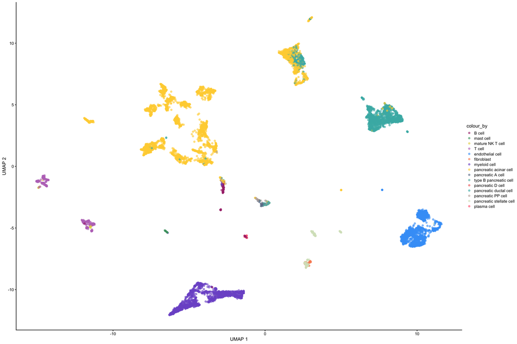

```r
sce <- runPCA(sce, ncomponents = 15)
sce <- runUMAP(sce)

g = plotReducedDim(sce, "UMAP", colour_by = "cell_type") +
  scale_colour_manual(values = pancreas_colours)
g
```

# Fit cell type prediction model

We will fit a relatively simple Random Forest model to predict cell type using the logcounts of the scRNA-seq data. We will use only the features that are common between the scRNA-seq and Xenium data.

```r
fit = randomForest(x = t(as.matrix(assay(sce, "logcounts"))),
                   y = sce$cell_type)
fit
```

```
##
## Call:
##  randomForest(x = t(as.matrix(assay(sce, "logcounts"))), y = sce$cell_type)
##                Type of random forest: classification
##                      Number of trees: 500
## No. of variables tried at each split: 19
##
##         OOB estimate of  error rate: 2.62%
## Confusion matrix:
##                          B cell mast cell mature NK T cell T cell
## B cell                      124         0                0      2
## mast cell                     0        53                0      0
## mature NK T cell              0         0               40      5
## T cell                        1         2                3    567
## endothelial cell              0         0                0      0
## fibroblast                    0         0                0      0
## myeloid cell                  2         0                0      0
## pancreatic acinar cell        1         1                0      0
## pancreatic A cell             0         0                0      0
## type B pancreatic cell        0         0                0      0
## pancreatic D cell             0         0                0      0
## pancreatic ductal cell        1         0                0      0
## pancreatic PP cell            0         0                0      0
## pancreatic stellate cell      0         0                0      0
## plasma cell                   0         0                0      0
##                          endothelial cell fibroblast myeloid cell
## B cell                                  0          0            4
## mast cell                               0          0            0
## mature NK T cell                        0          0            2
## T cell                                  0          0            0
## endothelial cell                     2088          0            0
## fibroblast                              0         22            0
## myeloid cell                            1          0         1844
## pancreatic acinar cell                  2          0            6
## pancreatic A cell                       0          0            0
## type B pancreatic cell                  0          0            0
## pancreatic D cell                       0          0            0
## pancreatic ductal cell                  0          0            0
## pancreatic PP cell                      0          0            0
## pancreatic stellate cell                2          2            1
```

[output cut: 50 more lines]

```
## B cell                                          0           4 0.138888889
## mast cell                                       0           0 0.000000000
## mature NK T cell                                0           0 0.148936170
## T cell                                          0           0 0.010471204
## endothelial cell                                0           0 0.005714286
## fibroblast                                     24           0 0.531914894
## myeloid cell                                    0           0 0.009667025
## pancreatic acinar cell                          0           0 0.013191182
## pancreatic A cell                               0           0 0.126760563
## type B pancreatic cell                          0           0 0.020202020
## pancreatic D cell                               0           0 1.000000000
## pancreatic ductal cell                          0           0 0.063759770
## pancreatic PP cell                              0           0 0.098591549
## pancreatic stellate cell                      382           0 0.027989822
## plasma cell                                     0          63 0.000000000
```

# Save the objects

We save the SingleCellExperiment object in the `../ProcessedData/` folder. We also save the fitted Random Forest object and place it in the `../analysisOutput/` folder.

```r
saveRDS(sce, file = "../processedData/sc_pancreas_sce.Rds")
saveRDS(fit, file = "../analysisOutput/sc_cell_type_RF_fit.Rds")
saveRDS(pancreas_colours, file = "../analysisOutput/pancreas_colours.Rds")
```